# Lista de Exercícios 2 - ADAR/UFSM

Andreza Dantas dos Santos

2021-02-16

## Critérios de Avaliação

> **Formato padrão de entrega**: só serão avaliadas as listas entregues no [padrão](https://lhmet.github.io/adar-ebook/exerc%C3%ADcios.html) especificado na instrução da referida lista. Entregas fora do padrão implica em nota mínima (zero). O Rmd deve ser baseado no template fornecido.

> **Identificação**: Arquivo .Rmd sem autoria acarreta uma penalização de 5%.

> **Prática de [R Markdown](https://lhmet.github.io/adar-ebook/r-markdown.html)**: A intenção ao solicitar a entrega em R Markdown é de incentivar a prática do R Markdown nas resoluções das questões, incluindo códigos e texto para discutir ou explicar sua solução. A penalização neste critério é até 5% do valor da questão..

> **Boas práticas**: Os códigos são avaliados quanto as boas práticas recomendadas no [livro](https://lhmet.github.io/adar-ebook/boas-pr%C3%A1ticas-para-c%C3%B3digos-de-boa-qualidade.html). Penalização de até 5% do valor questão.

> **Erros de digitação e ortografia**: como há recursos para verificação deste tipo de erro (ver [verificação ortográfica no RStudio](https://lhmet.github.io/adar-ebook/verifica%C3%A7%C3%A3o-ortogr%C3%A1fica.html)) eles são penalizados em até 5% do valor questão.

> **Reprodutibilidade**: o arquivo .Rmd deve rodar sem problemas e gerar o arquivo html com as respostas das questões.

> **Organização**: a resolução das questões devem ser feitas no espaço reservado para ela, ou seja, logo abaixo do enunciado da referida questão no arquivo .Rmd.

> **Adequação**: a lista foi concebida para você aplicar o aprendizado do conteúdo referente ao capítulo da lista. Portanto, a melhor solução é a que aplica as funções pertinentes ao conteúdo daquele capítulo e os pacotes recomendados.
1. Crie um vetor com os valores de $e^{x}cos{x}$ para os valores de $x = (3, 3.1, 3.2, ..., 6$).

```r
x <- c(seq(from = 3, to = 6, by = 0.1))

(y <- exp(x) * cos(x))
```

```
#>  [1] -19.884531 -22.178753 -24.490697 -26.773182 -28.969238 -31.011186
#>  [7] -32.819775 -34.303360 -35.357194 -35.862834 -35.687732 -34.685042
#> [13] -32.693695 -29.538816 -25.032529 -18.975233 -11.157417  -1.362099
#> [19]  10.632038  25.046705  42.099201  61.996630  84.929067 111.061586
#> [25] 140.525075 173.405776 209.733494 249.468441 292.486707 338.564378
#> [31] 387.360340
```

```
JDT> [1] 1
```

2. Crie os seguintes vetores.
   1. $(0.1^{3}\times0.2^{1}, 0.1^{6}\times0.2^{4}, ..., 0.1^{36}\times0.2^{34})$
   2. $(2, \frac{2^{2}}{2}, \frac{2^{3}}{3}, ..., \frac{2^{25}}{25})$

```r
a1 <- seq(3, len = 12, by = 3)
a2 <- seq(1, len = 12, by = 3)
a3 <- 1:25

(q_2a <- c(rep((0.1^a1 * 0.2^a2), len = 12)))
```

```
#>  [1] 2.000000e-04 1.600000e-09 1.280000e-14 1.024000e-19 8.192000e-25
#>  [6] 6.553600e-30 5.242880e-35 4.194304e-40 3.355443e-45 2.684355e-50
#> [11] 2.147484e-55 1.717987e-60
```

```r
(q_2b <- rep((2^a3 / a3), len = 24))
```

```
#>  [1] 2.000000e+00 2.000000e+00 2.666667e+00 4.000000e+00 6.400000e+00
#>  [6] 1.066667e+01 1.828571e+01 3.200000e+01 5.688889e+01 1.024000e+02
#> [11] 1.861818e+02 3.413333e+02 6.301538e+02 1.170286e+03 2.184533e+03
#> [16] 4.096000e+03 7.710118e+03 1.456356e+04 2.759411e+04 5.242880e+04
#> [21] 9.986438e+04 1.906502e+05 3.647221e+05 6.990507e+05
```

```
JDT> [1] 1
```

3. Reproduza a criação do vetor dias da semana (`dds`) mostrado abaixo.

```
domingo segunda   terca  quarta  quinta   sexta   sabado
      1       2       3       4       5       6        7
```

```r
(dds <- c(domingo = 1, segunda = 2, terca = 3, quarta = 4, quinta = 5, sexta = 6, sabado = 7))
```

```
#> domingo segunda   terca  quarta  quinta   sexta  sabado
#>       1       2       3       4       5       6       7
```

> JDT: falta de boas práticas, o código deve ir até 80 caracteres na linha. Use quebra de linha.

```
JDT> [1] 0.95
```

4. Interprete o resultado da seguinte operação:

```r
dds_nums <- c(
  5L, 2L, 5L, 2L, 7L, 7L, 2L,
  6L, 6L, 3L, 7L, 1L, 2L, 2L,
  5L, 7L, 3L, 2L, 6L, 4L, 1L
)
names(dds)[dds_nums]
```

Ao utilizar o sufixo `L` em um dado numérico `(numeric)`, o tipo de dado é definido como inteiro `(integer)`. Assim, em `dds_nums`, o vetor foi definido como `integer`, devido ao uso do `L` em cada elemento numérico.

`names(dds)[dds_nums]` retorna os “nomes” definidos em `dds` para o vetor `dds_nums`, que compartilha os elementos de `dds`.

> JDT: O aspecto chave era perceber para que serve o conceito de RECICLAGEM.

```
JDT> [1] 1
```

5. Para um ano ser bissexto, ele deve ser:
- divísivel por 4 (a divisão é exata com resto igual a zero)
- não pode ser divisível por 100 (a divisão não é exata, ou seja, o resto é diferente de zero)
- pode ser que seja divisível por 400: caso seja divisível por 400, a divisão deve ser exata, deixando o resto igual a zero.

  Com os critérios definidos acima, construa o código para:
  1. Verificar se os anos 1894, 1947, 1901, 1992, 1925, 2014, 1993, 1996, 1984, 1897, 2100, 2300 são bissextos.
  2. Mostre quais anos são bissextos.
  3. Usando o código para verificar se o ano é bissexto, gere um vetor nomeado `ndias` com o número de dias do ano para os anos do item (a).
  4. Programe como obter o total de anos com 366 dias?

```r
set.seed(3)
(anos <- c(sample(1890:2015, 10), 2100, 2300))
```

```
#>  [1] 1894 1947 1901 1992 1925 2014 1993 1996 1984 1897 2100 2300
```

```r
(condicao_1 <- c(anos %% 4))
```

```
#>  [1] 2 3 1 0 1 2 1 0 0 1 0 0
```

```r
(condicao_2 <- anos %% 100)
```

```
#>  [1] 94 47  1 92 25 14 93 96 84 97  0  0
```

```r
(condicao_3 <- anos %% 400)
```

```
#>  [1] 294 347 301 392 325  14 393 396 384 297 100 300
```

```r
# procure imprimir somente o que é pedido na questão
bissextos <- ifelse(
  test = (condicao_1 == 0) & (condicao_2 != 0) | (condicao_3 == 0),
  yes = "sim",
  no = "não"
)
bissextos
```

```
#>  [1] "não" "não" "não" "sim" "não" "não" "não" "sim" "sim" "não" "não" "não"
```

> Ano bissexto ímpar?

```r
(posicao_bissextos <- which(bissextos == "sim"))
```

```
#> [1] 4 8 9
```

```r
anos[posicao_bissextos]
```

```
#> [1] 1992 1996 1984
```

```r
ndias <- ifelse(
  test = (condicao_1 == 0) & (condicao_2 != 0) | (condicao_3 == 0),
  yes = 366,
  no = 365
)
names(ndias) <- anos
ndias
```

```
#> 1894 1947 1901 1992 1925 2014 1993 1996 1984 1897 2100 2300
#>  365  365  365  366  365  365  365  366  366  365  365  365
```

```r
total_bissextos <- ifelse(
  test = ndias == 366,
  yes = 1,
  no = 0
)
sum(total_bissextos)
```

```
#> [1] 3
```

```
JDT> [1] 1
```

6. Quais códigos para gerar os seguintes dados:

```
[1] -30   0   5  10  15  20  30
```

```
[1] 1.0 0.8 0.6 0.4 0.2 0.0
```

```
[1] -3.1415927 -2.4434610 -1.7453293 -1.0471976 -0.3490659  0.3490659
[7]  1.0471976  1.7453293  2.4434610  3.1415927
```

```
[1] -1 -1  0  0  0  1  1  1  1  2  2  2  2  2  3  3  3  3  3  3  4  4  4
[24]  4  4  4  4  5  5  5  5  5  5  5  5
```

```
[1] 5 5 5 5 5 4 4 4 4 3 3 3 2 2 1 2 2 3 3 3 4 4 4 4 5 5 5 5 5
```

```r
c(-30, seq(0, 20, by = 5), 30)
```

```
#> [1] -30   0   5  10  15  20  30
```

```r
seq(1, 0, by = -0.2)
```

```
#> [1] 1.0 0.8 0.6 0.4 0.2 0.0
```

```r
seq(-pi, pi, len = 10)
```

```
#>  [1] -3.1415927 -2.4434610 -1.7453293 -1.0471976 -0.3490659  0.3490659
#>  [7]  1.0471976  1.7453293  2.4434610  3.1415927
```

```r
rep(-1:5, times = 2:8)
```

```
#>  [1] -1 -1  0  0  0  1  1  1  1  2  2  2  2  2  3  3  3  3  3  3  4  4  4  4  4
#> [26]  4  4  5  5  5  5  5  5  5  5
```

```r
rep(c(5, 4, 3, 2, 1, 2, 3, 4, 5), c(5, 4, 3, 2, 1, 2, 3, 4, 5))
```

```
#>  [1] 5 5 5 5 5 4 4 4 4 3 3 3 2 2 1 2 2 3 3 3 4 4 4 4 5 5 5 5 5
```

> JDT: na (e) precisa digitar tudo isso? Como você pode codificar uma sequência de n° inteiros em R?

```r
# penalizacoes
p6 <- 0.25* 1/5
# nota questão
(nq6 <- 1 - p6)
```

```
#> [1] 0.95
```

7. Usando o mesmo código para solução em todos os itens abaixo, obtenha as seguintes sequências usando os vetores fornecidos.
1. v3 = (11, 0.25, 7, 2)

```
[1] 1 2 3 4
```

2. v2 = (11, 0.25)

```
[1] 1 2
```

3. v1 = (11)

```
[1] 1
```

4. v0 = ()

```
integer(0)
```

```r
v3 <- c(11, 0.25, 7, 2)
v2 <- v3[1:2]
v1 <- v3[1]
v0 <- c()

seq(along = v3)
```

```
#> [1] 1 2 3 4
```

```r
seq(along = v2)
```

```
#> [1] 1 2
```

```r
seq(along = v1)
```

```
#> [1] 1
```

```r
seq_along(v0)
```

```
#> integer(0)
```

```
JDT> [1] 1
```

8. Considere os seguintes dados horários de temperatura do ar ($T_{ar}$) registrados em duas estações meteorológicas, entre as 0 e 23 horas de um dado dia.

```r
tar_est1 <- c(
  14.92, 14.61, 14.32, 14.07, 13.84, 13.65, 13.56, 13.97, 15.08,
  16.5, 17.88, 19.08, 20.02, 20.66, 21.01, 21.05, 20.76, 20.05,
  18.77, 17.51, 16.67, 16.11, 15.66, 15.27
)
tar_est2 <- c(
  13.13, 13.01, 12.93, 12.87, 12.82, 12.81, 13.2, 14.22, 15.77,
  17.49, 19.2, 20.57, 21.49, 22.01, 22.03, 21.71, 20.84, 18.77,
  16.54, 15.13, 14.34, 13.81, 13.49, 13.28
)
```

> Dica: Faça um gráfico para visualizar as temperaturas das duas estações. Isso facilitará a solução.

**a.** Determine a média diária da $T_{ar}$ das duas estações arrendondando para uma casa decimal. Salve a média de cada estação nas variáveis `tmed_est1` e `tmed_est2`.

**b**. Utilizando as variáveis do item anterior, verifique usando comparação lógica, em qual estação o ambiente é mais quente?

**c**. Obtenha a 3ª maior temperatura do dia em cada estação.

**d**. Calcule a amplitude térmica diária ($ATD = T_{max}-T_{min}$, onde $T_{max}$: temperatura máxima dária e $T_{min}$: temperatura mínima dária) das estações 1 e 2, arrendondando para uma casa decimal. Salve os resultados nas variaveis `atd_est1` e `atd_est2`.

**e**. Qual o horário de ocorrência das temperaturas máximas e mínimas em cada estação? Salve os resultados nas variáveis `hmax_est{i}` e `hmin_est{i}`, com $i = 1, 2$.

**f**. Quando `tar_est2` é maior que `tar_est1` qual a maior diferença absoluta de temperatura entre as duas estações?

**g**. Qual a hora correspondende a ocorrência daquela maior diferença absoluta de temperatura obtida no item anterior?

**h**. O horário do pôr do sol pode ser estimado a partir da $T_{ar}$. Para o período após o horário de ocorrência da $T_{max}$ determina-se em qual horas ocorre a maior queda de $T_{ar}$ em relação a horas anterior. Estime o horário do pôr do sol para as duas estações (`hps_est{i}`).

**i**. Em quais horas as temperaturas das duas estações estão mais próximas uma da outra, ou seja com menos de 0,5°C de diferença ?

**j**. Calcule a temperatura média diária usando os seguintes métodos para estação 2.

$T_{med_{1}} = (T_{max} + T_{min})/2$, salvando em uma variável `tar_met1`.

$T_{med_{2}} = (T_{max} + T_{min} + T_{9} + 2T_{21})/5$, salvando em uma variável `tar_met2`.

$T_{med_{3}} = (T_{7} + T_{14} + 2T_{21})/4$, salvando em uma variável `tar_met2`.

Compare este resultados com aqueles obtidos no item **a**. Qual é melhor?

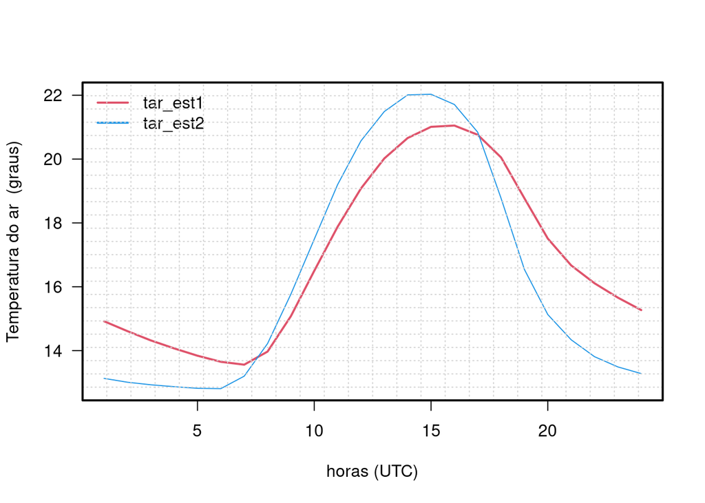

```r
horas <- 0:23
names(tar_est1) <- horas
names(tar_est2) <- horas
plot(tar_est1,
     type = "l",
     lwd = 2,
     col = 2,
     # main = "",
     xlab = "horas (UTC)",
     ylab = "Temperatura do ar  (graus)",
     yaxt = "n",
     ylim = c(min(tar_est2), max(tar_est2))
)
points(tar_est2, type = "l", col = 4)
legend("topleft",
       legend = c("tar_est1", "tar_est2"),
       col = c(2, 4),
       lwd = 2,
       bty = "n")
grid(nx = 24)
box(lwd = 2)
axis(side = 2, las = 1)
```

> Graus Celsius é a unidade de Temperatura (°C).

```r
tmed_est1 <- mean(tar_est1)
tmed_est2 <- mean(tar_est2)

(tmed_est1 <- round(tmed_est1, 1))
```

```
#> [1] 16.9
```

```r
(tmed_est2 <- round(tmed_est2, 1))
```

```
#> [1] 16.3
```

```r
if (tmed_est1 - tmed_est2 == 0)
{print("tmed_est1 = tmed_est2")}

if(tmed_est1 - tmed_est2 > 0)
{print("tmed_est1")} else {
  print("tmed_est2")
}
```

```
#> [1] "tmed_est1"
```

```r
tar_est1[order(tar_est1, decreasing = TRUE)][3]
```

```
#>    16
#> 20.76
```

```r
tar_est2[order(tar_est2, decreasing = TRUE)][3]
```

```
#>    15
#> 21.71
```

```r
atd_est1 <- max(tar_est1) - min(tar_est1)
(atd_est1 = round(atd_est1, 1))
```

```
#> [1] 7.5
```

```r
atd_est2 <- max(tar_est2) - min(tar_est2)
(atd_est2 = round(atd_est2, 1))
```

```
#> [1] 9.2
```

```r
(hmax_est1 <- c(horas[which(tar_est1 == max(tar_est1))]))
```

```
#> [1] 15
```

```r
(hmax_est2 <- c(horas[which(tar_est2 == max(tar_est2))]))
```

```
#> [1] 14
```

```r
(hmin_est1 <- c(horas[which(tar_est1 == min(tar_est1))]))
```

```
#> [1] 6
```

```r
(hmin_est2 <- c(horas[which(tar_est2 == min(tar_est2))]))
```

```
#> [1] 5
```

```r
dif_tar <- abs(tar_est2 - tar_est1)
dif_tar[which.max(dif_tar)]
```

```
#>   19
#> 2.38
```

```r
#max(tar_est2 - tar_est1)
## ou
# (inds_tar2_maior <- tar_est2 > tar_est1)
# max_diff_tar <- max(
#   tar_est2[inds_tar2_maior] - tar_est1[inds_tar2_maior]
#   #abs(tar_est2[inds_tar2_maior] - tar_est1[inds_tar2_maior])
# )
# max_diff_tar
```

> Você esqueceu de ‘QUANDO A tar_est2 É MAIOR QUE tar_est1 …’

```r
(h_dif_tar <- c(horas[which.max(dif_tar)]))
```

```
#> [1] 19
```

> Erro se propaga.

```r
hps_tar1 <- tar_est1[horas > hmax_est1]
hps_est1 <- diff(hps_tar1)
(hps_est1 <- names(which.min(hps_est1)))
```

```
#> [1] "18"
```

```r
hps_tar2 <- tar_est2[horas > hmax_est2]
hps_est2 <- diff(hps_tar2)
(hps_est2 <- names(which.min(hps_est2)))
```

```
#> [1] "18"
```

```r
(temps_prox <- c(horas[which(abs(tar_est1 - tar_est2) < 0.5)]))
```

```
#> [1]  6  7 16
```

```r
(tar_met1 <- (max(tar_est2) + min(tar_est2)) / 2)
```

```
#> [1] 17.42
```

```r
(tar_met2 <- (max(tar_est2) + min(tar_est2) + (tar_est2[10]) + (2 * tar_est2[22])) / 5)
```

```
#>     9
#> 15.99
```

```r
(tar_met3 <- (tar_est2[8] + tar_est2[15] + (2 * tar_est2[22])) / 4)
```

```
#>       7
#> 15.9675
```

> Falta de boas práticas: de onde saíram os números 8, 10, 15 e 22? colocados na mão? Se tivesse que fazer isso pra 1000 estações faria na mão? Pense como programadora! Eles deveriam ser determinados automaticamente baseado nas informações do enunciado.

Por padrão, a equação `tar_met2` estima melhor os valores médios diários.

> Você poderia mostrar isso com seu código. Como você chegou a essa conclusão? que cálculo mental não expresso aqui que você fez para afirmar isso?

```r
dif_abs_mets_est2 <- c(
  m1 = tar_met1 - tmed_est2,
  m2 = tar_met2 - tmed_est2,
  m3 = tar_met3 - tmed_est2
)
dif_abs_mets_est2
```

```
#>      m1    m2.9    m3.7
#>  1.1200 -0.3100 -0.3325
```

```r
dif_abs_mets_est2[which.min(abs(dif_abs_mets_est2))]
```

```
#>  m2.9
#> -0.31
```

> Não entendi este comentário abaixo. Acho que você se confundiu.

Mas o valor da média calculada com a função `mean` é um valor aproximado ao da equação padrão `tar_met2`, o que, também, nos dá uma boa aproximação.

```
JDT> [1] 0.7333333
```

9. Calcule a temperatura do ar horária usando o **modelo de onda** para representação do ciclo diário da temperatura do ar, descrito pelas seguintes equações:

$$\left\{\begin{matrix}
h_{T_{min}}\leq h < h_{T_{max}}, & T_{calc} = \bar{T} - A \, cos\left ( arg \right )\\
demais\; horas, & T_{calc} = \bar{T} + A \, cos\left ( arg \right )
\end{matrix}\right.$$

onde:

$$\bar{T} = \left ( \frac{T_{max} + T_{min}}{2} \right )$$

e

$$A =\left ( \frac{T_{max}-T_{min}}{2} \right )$$

**a**. Aplique o método acima para estação 1 e 2 substituindo os valores de $T_{max}$, $T_{min}$, $h_{T_{max}}$, $h_{T_{max}}$, adequadamente.

**b**. Calcule o RMSE nos dois casos. $RMSE = \sqrt{\frac{1}{n}\sum_{i=1}^{n}\left (T_{calc}-T_{obs} \right )^{2}}$

**c**. Calcule a correlação ($r$) nos dois casos. A barra representa a média aritmética.

$$r = \frac{\sum_{i=1}^{n} (T_{obs}-\bar{T}_{obs})(T_{calc}-\bar{T}_{calc}))}{\sqrt{\sum_{i = 1}^{n} (T_{obs}-\bar{T}_{obs})^{2}(T_{calc}-\bar{T}_{calc})^{2})}}$$
a.

```r
#options(digits = 3)
tmed_est1 <- (max(tar_est1) + min(tar_est1)) / 2
A1 <- (max(tar_est1) - min(tar_est1)) / 2

arg_est1_c1 <- ifelse(test = (horas < hmin_est1),
                      # atribuição de variável dentro de argumento?
                      # nunca mostrei o uso do ifelse desta forma
                      #yes = arg_est1_c1 <- pi * ((horas + 10) / (10 + hmin_est1)),
                      yes = pi * ((horas + 10) / (10 + hmin_est1)),
                      no = 0
                      # uso de ';'? usa quebra de linha como indicado pelas boas práticas
)

arg_est1_c2 <- ifelse(test = (hmin_est1 <= horas & horas < hmax_est1),
                      # atribuição de variável dentro de argumento?
                      # nunca mostrei o uso do ifelse desta forma
                      #yes = arg_est1_c2 <- pi * ((horas - hmin_est1) / (14 - hmin_est1)),
                      yes = pi * ((horas - hmin_est1) / (14 - hmin_est1)),
                      no = arg_est1_c1
)

arg_est1 <- ifelse(test = (horas > hmax_est1),
                      #yes = arg_est1 <- pi * ((14 - horas) / (10 + hmin_est1)),
                      yes = pi * ((14 - horas) / (10 + hmin_est1)),
                      no = arg_est1_c2)

(tcalc_est1 <- ifelse(test =  (hmin_est1 <= horas & horas < hmax_est1),
                      #yes = tcalc_est1 <- tmed_est1 - A1 * cos(arg_est1),
                      yes = tmed_est1 - A1 * cos(arg_est1),
                      #no = tcalc_est1 <- tmed_est1 + A1 * cos(arg_est1)
                      no =  tmed_est1 + A1 * cos(arg_est1)
))
```

```
#>  [1] 15.87185 15.22439 14.65689 14.19115 13.84507 13.63196 13.56000 13.84507
#>  [9] 14.65689 15.87185 17.30500 18.73815 19.95311 20.76493 21.05000 21.05000
#> [17] 20.76493 20.41885 19.95311 19.38561 18.73815 18.03561 17.30500 16.57439
```

```r
tmed_est2 <- (max(tar_est2) + min(tar_est2)) / 2
A2 <- (max(tar_est2) - min(tar_est2)) / 2

arg_est2_c1 <- ifelse(test = (horas < hmin_est2),
                      yes = arg_est2_c1 <- pi * ((horas + 10) / (10 + hmin_est2)),
                      no = 0
); arg_est2_c2 <- ifelse(test = (hmin_est2 <= horas & horas < hmax_est2),
                         yes = arg_est2_c2 <- pi * ((horas - hmin_est2) / (14 - hmin_est2)),
                         no = arg_est2_c1
); arg_est2 <- ifelse(test = (horas > hmax_est2),
                      yes = arg_est2 <- pi * ((14 - horas) / (10 + hmin_est2)),
                      no = arg_est2_c2)

(tcalc_est2 <- ifelse(test =  (hmin_est2 <= horas & horas < hmax_est2),
                      yes = tcalc_est2 <- tmed_est2 - A2 * cos(arg_est2),
                      no = tcalc_est2 <- tmed_est2 + A2 * cos(arg_est2)
))
```

```
#>  [1] 15.11500 14.33531 13.69043 13.20856 12.91074 12.81000 13.08802 13.88854
#>  [9] 15.11500 16.61948 18.22052 19.72500 20.95146 21.75198 22.03000 21.92926
#> [17] 21.63144 21.14957 20.50469 19.72500 18.84457 17.90188 16.93812 15.99543
```

```r
(RMSE1 <- sqrt(mean((tcalc_est1 - tar_est1)^2)))
```

```
#> [1] 0.9108654
```

```r
(RMSE2 <- sqrt(mean((tcalc_est2 - tar_est2)^2)))
```

```
#> [1] 2.133115
```

```r
(r1 <- (mean((tar_est1 - mean(tar_est1)) * (tcalc_est1 - mean(tcalc_est1)))) / sqrt(mean((tar_est1 - mean(tar_est1))^2 * (tcalc_est1 - mean(tcalc_est1))^2)))
```

```
#> [1] 0.7811162
```

```r
(r2 <- (mean((tar_est2 - mean(tar_est2)) * (tcalc_est2 - mean(tcalc_est2)))) / sqrt(mean((tar_est2 - mean(tar_est2))^2 * (tcalc_est2 - mean(tcalc_est2))^2)))
```

```
#> [1] 0.7382575
```

> Você precisa enter a diferença entre somatório $\sum_{i=1}^{n}x_{i}$ (`sum(x)` on R) e média $\frac{1}{n}\sum_{i=1}^{n}x_{i}$ (`mean(x)` on R).

> Corrija seu resultado comparando com o resultado de `cor(tar_obs, tar_calc)`.

```
JDT> [1] 0.6666667
```

```
JDT>  nq1  nq2  nq3  nq4  nq5  nq6  nq7  nq8  nq9
JDT> 1.00 1.00 0.95 1.00 1.00 0.95 1.00 0.73 0.67
JDT> Nota: 9.2
```